# 在线课程-网络数据结构Task6

杜兴兴

2021/3/23

## 准备工作

```r
# 清除工作环境
rm(list = ls())
library(igraph)  # 加载必要包
```

## 任务一

根据定义计算个体的度degree，并且将其按degree倒序排列。请你给这段代码加上注释，重点是学习ddply这个函数。

```r
# install.packages("plyr")
library(plyr)

data = read.csv("../A2_data/dat.csv",stringsAsFactors = F) # 导入数据，字符变量不作为因子变量读入

degree = ddply(data,.(id),nrow)                            # 对id变量进行分组统计

colnames(degree) = c('id', 'degree')                       # 变量重命名

degree = degree[order(degree$degree,decreasing = T),]      # 按照degree变量降序排列

head(degree)                                               # 查看前6个数据
```

```
##              id degree
## 3647 6804595686      8
## 7069 6875029620      8
## 3738 6804637788      7
## 4099 6815400034      7
## 5118 6844329955      7
## 6835 6870803337      7
```

## 任务二

根据定义计算个体的联系强度，并且与degree合并。结果请按id排序。给这段代码加上注释，重点学习ddply函数和merge函数。

```r
comm_sum_time = ddply(data, .(id), function(x){                   # 按照id进行分组统计
    # 统计的方式根据自定义函数（对每个id的comm_time求和）
    sum(x$comm_time)
})

colnames(comm_sum_time) = c('id', 'comm_sum_time')                # 变量重命名

tmp_data = merge(degree, comm_sum_time, by = 'id')      # 根据id变量对两个数据集横向全连接

tmp_data$comm_index = tmp_data$comm_sum_time / tmp_data$degree   # 计算个体的联系强度

tmp_data = tmp_data[order(tmp_data$id), ]               # 按照id变量升序排列

head(tmp_data[, c('id', 'comm_index')])                 # 查看id,comm_index变量的前6行
```

```
##           id comm_index
## 1 1445479496       7.38
## 2 1445480735       1.12
## 3 1445481123       3.80
## 4 1445481235       2.50
## 5 1445481336       2.03
## 6 1445482323       1.05
```

## 任务三

根据定义计算个体信息熵，结果请按信息熵倒序排列。给这段代码添加注释，确保你理解了代码的含义。

```r
tmp_data2 = merge(data, tmp_data[, c('id', 'comm_sum_time')]) # 默认按照共同变量(id)进行全连接

tmp_data2$p = tmp_data2$comm_time / tmp_data2$comm_sum_time  # i与j的童话时长所占比例

E = ddply(tmp_data2, .(id), function(x){                     # 按照id变量分组统计信息熵
    # 计算信息熵的公式
  -sum(x$p * log(x$p))
})

colnames(E) = c('id', 'entropy')                             # 对变量重命名

E = E[order(E$entropy, decreasing = T), ]                    # 按照信息熵倒序排列

head(E)                                                      # 查看前6行
```

```
##              id  entropy
## 6835 6870803337 1.881537
## 3647 6804595686 1.870905
## 4100 6815400358 1.701763
## 7069 6875029620 1.699261
## 6888 6871251905 1.697690
## 3651 6804596250 1.672912
```

## 任务四

任选一个自变量绘制与因变量的分组箱线图。这里以当月花费为例，你可以选择其他变量来做展示。请给出一定的解读。

```r
data <- read.csv('../A2_data/train.csv')
data$churn <- factor(data$churn, levels = c(0,1),labels = c('非流失','已流失'))
summary(data)
```

```
##        ID            tenure          expense             degree
##  Min.   :    1   Min.   : 184.0   Min.   :  0.4047   Min.   :  0.699
##  1st Qu.:12088   1st Qu.: 534.7   1st Qu.: 97.7690   1st Qu.: 31.174
##  Median :24281   Median : 993.5   Median :133.9911   Median : 54.596
##  Mean   :24224   Mean   :1256.1   Mean   :157.2385   Mean   : 64.875
##  3rd Qu.:36348   3rd Qu.:1636.4   3rd Qu.:200.1375   3rd Qu.: 88.534
##  Max.   :48393   Max.   :4479.6   Max.   :429.7999   Max.   :212.862
##    tightness         entropy         chgexpense         chgdegree
##  Min.   :-2.355   Min.   :0.4846   Min.   :-0.79261   Min.   :-0.992063
##  1st Qu.: 5.406   1st Qu.:2.4177   1st Qu.:-0.07968   1st Qu.:-0.159091
##  Median : 7.959   Median :3.0005   Median : 0.00000   Median :-0.009615
##  Mean   : 9.236   Mean   :2.9491   Mean   :-0.01584   Mean   : 0.011054
##  3rd Qu.:11.629   3rd Qu.:3.5461   3rd Qu.: 0.03222   3rd Qu.: 0.153846
##  Max.   :31.434   Max.   :5.0324   Max.   : 0.79717   Max.   : 1.187500
##     churn
##  非流失:43999
##  已流失:  518
##
##
##
##
```

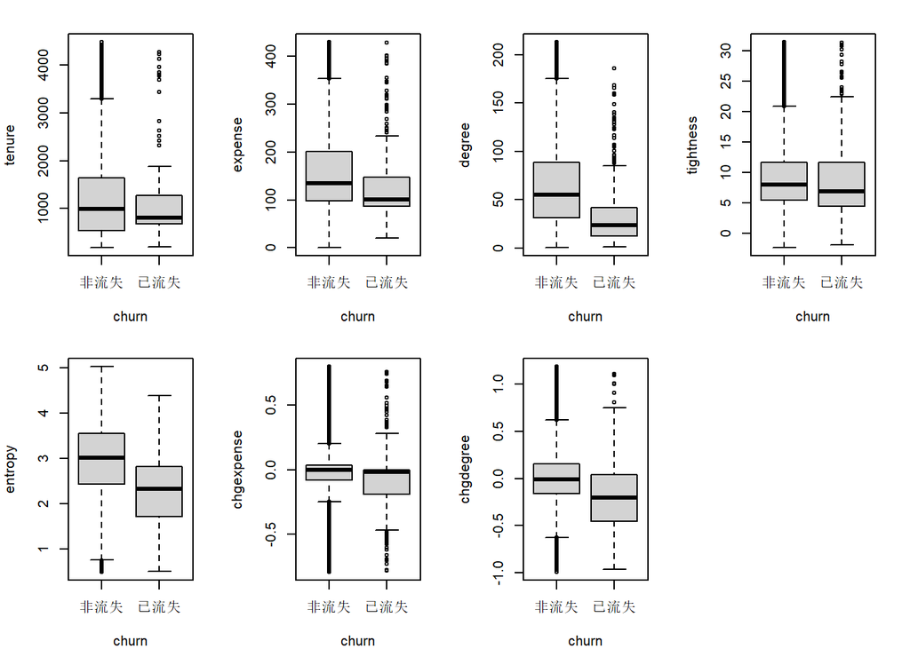

```r
# 绘制箱线图
op <- par(no.readonly = F,mar = c(4,4,2,2) )
par(mfrow=c(2,4))
for(i in c(2:8)){
        boxplot(data[,i]~churn, data=data,ylab = names(data)[i])
}
```

## 任务五

构建客户流失模型（逻辑回归模型）并给出系数的解读。此处已经给出了解读的示例，你可以挑选1-2个变量，解读现象背后的原因。尤其是能够体现网络结构的自变量，其对流失的影响能带来什么启发？

```r
model0 <- glm(churn~tenure+expense+degree+tightness+entropy+chgdegree+chgexpense,
    family = binomial(link = 'logit'),
    data = data)
summary(model0)
```

```
##
## Call:
## glm(formula = churn ~ tenure + expense + degree + tightness +
##     entropy + chgdegree + chgexpense, family = binomial(link = "logit"),
##     data = data)
##
## Deviance Residuals:
##     Min       1Q   Median       3Q      Max
## -0.7727  -0.1692  -0.1152  -0.0713   4.1197
##
## Coefficients:
##               Estimate Std. Error z value Pr(>|z|)
## (Intercept) -1.985e+00  2.501e-01  -7.937 2.07e-15 ***
## tenure      -3.241e-04  6.962e-05  -4.655 3.24e-06 ***
## expense     -2.881e-03  7.128e-04  -4.042 5.31e-05 ***
## degree      -1.931e-02  3.168e-03  -6.098 1.08e-09 ***
## tightness   -3.807e-02  8.224e-03  -4.630 3.67e-06 ***
## entropy     -2.258e-01  1.060e-01  -2.130  0.03315 *
## chgdegree   -1.305e+00  1.601e-01  -8.156 3.47e-16 ***
## chgexpense  -6.605e-01  2.224e-01  -2.970  0.00298 **
## ---
## Signif. codes:  0 '***' 0.001 '**' 0.01 '*' 0.05 '.' 0.1 ' ' 1
##
## (Dispersion parameter for binomial family taken to be 1)
##
##     Null deviance: 5643.9  on 44516  degrees of freedom
## Residual deviance: 5032.5  on 44509  degrees of freedom
## AIC: 5048.5
##
## Number of Fisher Scoring iterations: 8
```

根据如上的模型结果可以看出，个体信息熵通过了显著性检验，且个体信息熵的估计系数为负数，说明个体信息熵越大，说明通话分布的越均匀，此时流失概率越低。而个体信息熵体现的是通话时长的离散程度，简而言之，熵越大，离散程度越大，也即根不同的人打电话时长都比较平均。模型结果说明未流失客户的通话时长的分布要高于流失客户，未流失客户通话时长的离散程度更大。

## 任务六

绘制人群细分柱状图；

根据模型给出每个样本的预测流失概率值，按照预测值从高到低对样本进行排序，例如只覆盖前10%的样本，计算对应的真实流失的样本数占所有流失样本数的比例，记为捕获率，以此类推，覆盖不同比例的样本，就可以计算不同的覆盖率对应的捕获率，从而得到覆盖率捕获率曲线。

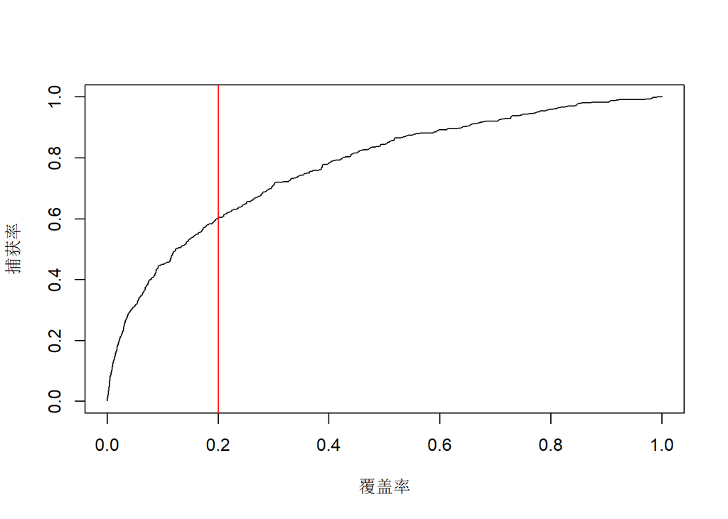

```r
#按预测概率排序后的id
id_pre <- data$ID[order(model0$fitted.values, decreasing = T)]
#真实流失的客户id
id_loss <- data$ID[data$churn=='已流失']
#计算捕获率向量
buhuo <- ifelse(id_pre%in%id_loss,1,0)
capture_rate <- cumsum(buhuo)/sum(data$churn=='已流失')
#计算覆盖率向量
cover_rate <- 1:length(capture_rate)/length(capture_rate)
plot(cover_rate, capture_rate,type='l',xlab='覆盖率',ylab='捕获率')
abline(v=0.2, col='red')
```

```r
#读入测试集
test <- read.csv('../A2_data/test.csv')
#预测概率
pre <- predict(model0, test,type='response')
#将概率预测值与实际流失情况放在一个数据框d中
d <- data.frame(pre = pre, true = test$churn)
#按预测概率从高到低排序
d <- d[order(d$pre), ]

#进行等宽分组，分为5组，记录在d中
# install.packages("infotheo")
library(infotheo)
```

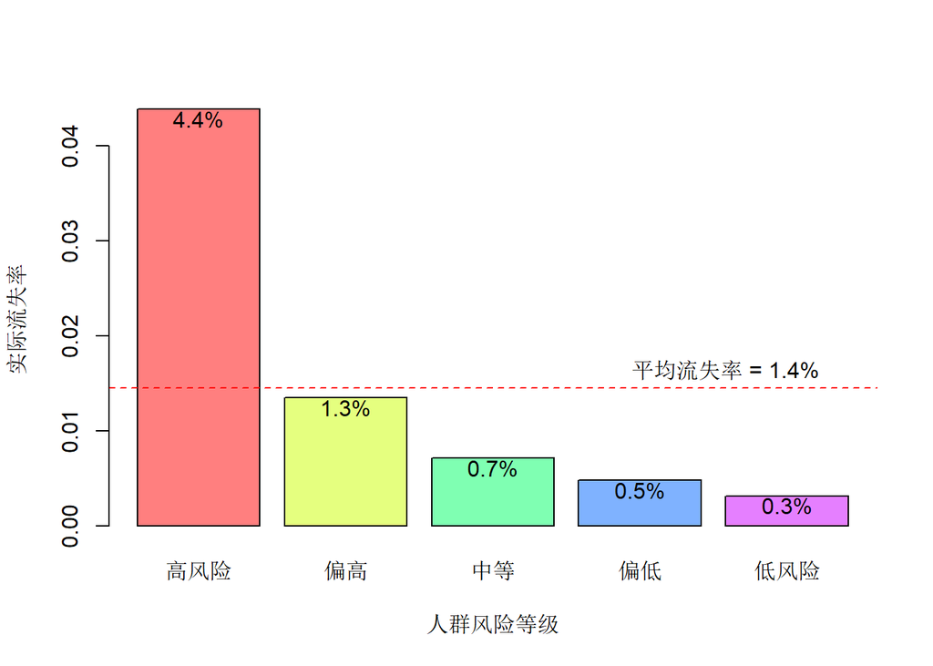

```r
s <- discretize(d$pre, 'equalfreq', 5)
d <- cbind(d,s)
d$X <- factor(d$X, levels = c(5:1),
              labels = c('高风险','偏高','中等','偏低','低风险'))

#分组计算实际流失率
library(plyr)
t <- ddply(d, .(X), summarize, lossrate = mean(true))

#绘制条形图，横轴为组，纵轴为实际流失率
b <- barplot(t$lossrate, col = rainbow(5, alpha = 0.5),
        names.arg = c('高风险','偏高','中等','偏低','低风险'),
        xlab = '人群风险等级', ylab = '实际流失率')
labels <- paste0(round(t$lossrate,3)*100,'%')
text(1:5*1.2-0.5, t$lossrate-0.001, labels)
#计算整体流失率，添加平均线
abline(h=mean(test$churn), col = 'red', lty = 2)
text(5 ,mean(test$churn)+0.002,paste0('平均流失率 = ', as.character(round(mean(test$churn),3)*100), '%'))
```